# Assignment_w8 - Option 2

Jakob Grøhn Damgaard

11/2/2020

In this markdown file, I intend to web-scrape data containing information about the golf players with the most PGA Tour wins throughout history. The data will be scraped from the following Wikipedia article: https://en.wikipedia.org/wiki/List_of_golfers_with_most_PGA_Tour_wins

This data will the be cleaned in order to produce a nice visualization of the top 25 players showing their wins against their yearly win rate.

# Solution

First, install a handful of classic R packages and load their libraries:

- `rvest` for web-scraping
- `dplyr` for data-wrangling
- `tidyr` for data transformation
- `stringr` for string manipulation
- `janitor` for clean headers that your OCD will love you for

```r
library(pacman)
p_load(rvest, dplyr, tidyr, stringr, janitor, tidyverse, ggrepel)
```

## Scraping the data

We start by defining a URL and reading the HTML from the URL.

```r
url <- "https://en.wikipedia.org/wiki/List_of_golfers_with_most_PGA_Tour_wins"
# Scraping the website
url_html <- read_html(url)
```

Afterwards, we use load the data from a specific HTML-node into a table, and create a tibble.

```r
# Extracting the desired data table
whole_table <- url_html %>%
 html_node(xpath = '//*[@id="mw-content-text"]/div[1]/table') %>%
 html_table(fill = TRUE)

# Inspecting the data
whole_table %>% head()
```

```
##   Rank         Name[a] Year of birthand death       Country Wins Majors[b]
## 1    1     Sam Snead H              1912–2002 United States   82         7
## 2    1   Tiger Woods H                  1975– United States   82        15
## 3    3 Jack Nicklaus H                  1940– United States   73        18
## 4    4     Ben Hogan H              1912–1997 United States   64         9
## 5    5 Arnold Palmer H              1929–2016 United States   62         7
## 6    6  Byron Nelson H              1912–2006 United States   52         5
##   Winningspan Span(years)
## 1   1936–1965          30
## 2   1996–2019          24
## 3   1962–1986          25
## 4   1938–1959          22
## 5   1955–1973          19
## 6   1935–1951          17
```

Following screenshot shows how the ‘xpath’ leading to the requested data table is found:

[figure not shown]

## Pre-processing the data

```r
# Turning data into a tibble
pga_tour_wins <- as_tibble(whole_table)

# Extracting only the 25 players with most wins
pga_tour_wins <- pga_tour_wins[0:25,]

# Renaming column names
pga_tour_wins <-
  rename(pga_tour_wins, 'Name'= 'Name[a]',
         'Birth_death' = 'Year of birthand death',
         'Majors' = 'Majors[b]',
         'Span' = 'Span(years)')

# Add column indicating if players is still alive
pga_tour_wins$Still_alive <- grepl('–$', pga_tour_wins$Birth_death)

# Removing unnecessary 'H' from all names
pga_tour_wins$Name <- gsub('.{2}$', '', pga_tour_wins$Name)
```

## Visualizing the data

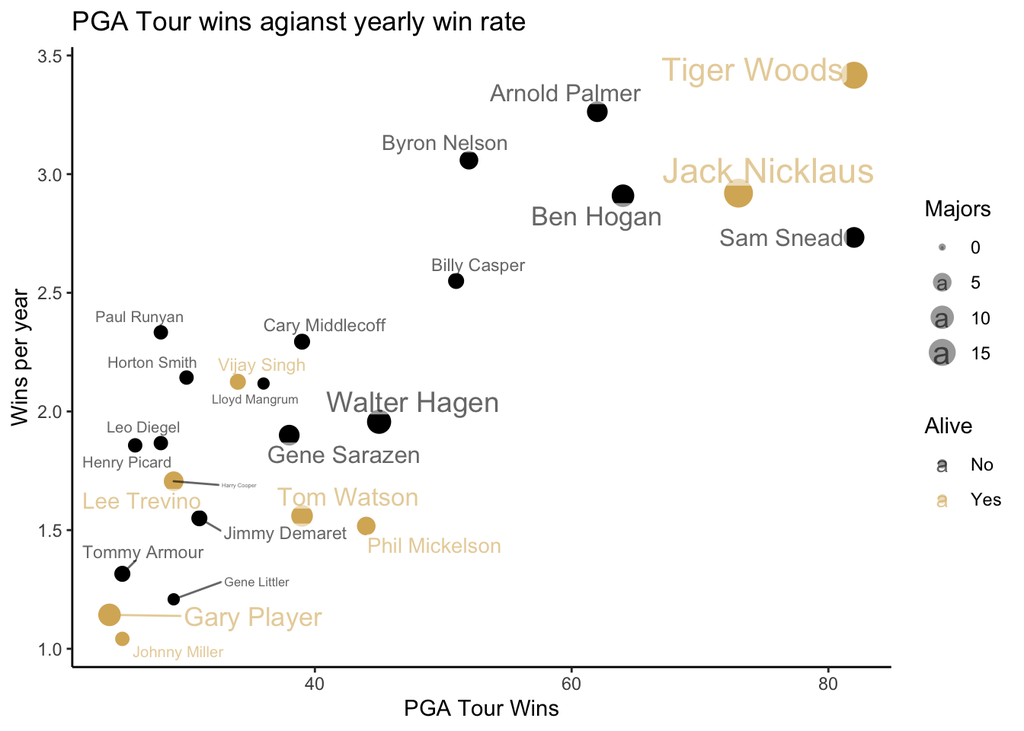

```r
# Plotting total wins against  wins per year
ggplot(pga_tour_wins, aes(Wins, Wins/Span, label = Name, size = Majors, color = Still_alive)) +
  geom_point() +
  geom_label_repel(aes(label=Name), # Adding labels to points
                   label.size = NA,
                   alpha = 0.6,
                   label.padding=.1,
                   na.rm=TRUE) +
  theme_classic() + # Setting prettier  theme
  labs(x = "PGA Tour Wins", # Defining all labels
       y = "Wins per year",
       title ="PGA Tour wins agianst yearly win rate")+
  scale_color_manual(name = "Alive", labels = c("No", "Yes"), values = c("black","#d8b365")) # Customizing legend for alive/not alive
```

As can be inferred from the legends displayed on the plot, the size of the labels correspond to the number of major events that the respective players have won and the color of the labels reveal whether the player is presently still alive. The visualization shows that the players with the most wins overall also seem to be the players who have performed with the highest average yearly win-rates. This finding was also expected.